# ML_PCA_044sgy

### 1.导入必要的库

```python
import matplotlib.pyplot as plt  # 导入matplotlib库并将其命名为plt
```

```python
from sklearn.datasets import load_iris  # 从sklearn库中导入load_iris函数
```

```python
from sklearn.decomposition import PCA  # 从sklearn库中导入PCA模块
```

```python
import pandas as pd  # 导入pandas库并将其命名为pd
import numpy as np  # 导入numpy库并将其命名为np
```

### 2.载入鸢尾花数据集

```python
iris = load_iris()  # 使用load_iris函数载入鸢尾花数据集
```

```python
y = iris.target  # 将目标变量赋值给y
print(y)        #输出y的值
print("y的形状为：{}".format(y.shape)) # 输出y的形状大小
```

```
[0 0 0 0 0 0 0 0 0 0 0 0 0 0 0 0 0 0 0 0 0 0 0 0 0 0 0 0 0 0 0 0 0 0 0 0 0
 0 0 0 0 0 0 0 0 0 0 0 0 0 1 1 1 1 1 1 1 1 1 1 1 1 1 1 1 1 1 1 1 1 1 1 1 1
 1 1 1 1 1 1 1 1 1 1 1 1 1 1 1 1 1 1 1 1 1 1 1 1 1 1 2 2 2 2 2 2 2 2 2 2 2
 2 2 2 2 2 2 2 2 2 2 2 2 2 2 2 2 2 2 2 2 2 2 2 2 2 2 2 2 2 2 2 2 2 2 2 2 2
 2 2]
y的形状为：(150,)
```

```python
X = iris.data  # 将特征变量赋值给X
print(X)       #输出X的值
print("X的形状为: {}".format(X.shape))  # 输出X的形状大小
```

```
[[5.1 3.5 1.4 0.2]
 [4.9 3.  1.4 0.2]
 [4.7 3.2 1.3 0.2]
 [4.6 3.1 1.5 0.2]
 [5.  3.6 1.4 0.2]
 [5.4 3.9 1.7 0.4]
 [4.6 3.4 1.4 0.3]
 [5.  3.4 1.5 0.2]
 [4.4 2.9 1.4 0.2]
 [4.9 3.1 1.5 0.1]
 [5.4 3.7 1.5 0.2]
 [4.8 3.4 1.6 0.2]
 [4.8 3.  1.4 0.1]
 [4.3 3.  1.1 0.1]
 [5.8 4.  1.2 0.2]
 [5.7 4.4 1.5 0.4]
 [5.4 3.9 1.3 0.4]
 [5.1 3.5 1.4 0.3]
 [5.7 3.8 1.7 0.3]
 [5.1 3.8 1.5 0.3]
 [5.4 3.4 1.7 0.2]
 [5.1 3.7 1.5 0.4]
 [4.6 3.6 1.  0.2]
 [5.1 3.3 1.7 0.5]
 [4.8 3.4 1.9 0.2]
 [5.  3.  1.6 0.2]
 [5.  3.4 1.6 0.4]
 [5.2 3.5 1.5 0.2]
 [5.2 3.4 1.4 0.2]
 [4.7 3.2 1.6 0.2]
 [4.8 3.1 1.6 0.2]
 [5.4 3.4 1.5 0.4]
 [5.2 4.1 1.5 0.1]
 [5.5 4.2 1.4 0.2]
 [4.9 3.1 1.5 0.2]
 [5.  3.2 1.2 0.2]
 [5.5 3.5 1.3 0.2]
 [4.9 3.6 1.4 0.1]
 [4.4 3.  1.3 0.2]
 [5.1 3.4 1.5 0.2]
```

[output cut: 96 more lines]

```
 [6.3 3.4 5.6 2.4]
 [6.4 3.1 5.5 1.8]
 [6.  3.  4.8 1.8]
 [6.9 3.1 5.4 2.1]
 [6.7 3.1 5.6 2.4]
 [6.9 3.1 5.1 2.3]
 [5.8 2.7 5.1 1.9]
 [6.8 3.2 5.9 2.3]
 [6.7 3.3 5.7 2.5]
 [6.7 3.  5.2 2.3]
 [6.3 2.5 5.  1.9]
 [6.5 3.  5.2 2. ]
 [6.2 3.4 5.4 2.3]
 [5.9 3.  5.1 1.8]]
X的形状为: (150, 4)
```

```python
pd.DataFrame(X)  # 将特征变量X转换为DataFrame形式，以便快速查看数据
```

|  | 0 | 1 | 2 | 3 |
| --- | --- | --- | --- | --- |
| 0 | 5.1 | 3.5 | 1.4 | 0.2 |
| 1 | 4.9 | 3.0 | 1.4 | 0.2 |
| 2 | 4.7 | 3.2 | 1.3 | 0.2 |
| 3 | 4.6 | 3.1 | 1.5 | 0.2 |
| 4 | 5.0 | 3.6 | 1.4 | 0.2 |
| ... | ... | ... | ... | ... |
| 145 | 6.7 | 3.0 | 5.2 | 2.3 |
| 146 | 6.3 | 2.5 | 5.0 | 1.9 |
| 147 | 6.5 | 3.0 | 5.2 | 2.0 |
| 148 | 6.2 | 3.4 | 5.4 | 2.3 |
| 149 | 5.9 | 3.0 | 5.1 | 1.8 |

150 rows × 4 columns

### 3.使用PCA进行降维

```python
pca = PCA(n_components=2)  # 创建一个PCA对象，设置降维后的维度为2
```

```python
pca = pca.fit(X)  # 对特征变量X进行PCA降维拟合
print(pca)
```

```
PCA(n_components=2)
```

```python
X_dr = pca.transform(X)  # 将原始数据集X降维
pd.DataFrame(X_dr)  # 将降维后的特征变量X_dr转换为DataFrame形式，以便快速查看数据
```

|  | 0 | 1 |
| --- | --- | --- |
| 0 | -2.684126 | 0.319397 |
| 1 | -2.714142 | -0.177001 |
| 2 | -2.888991 | -0.144949 |
| 3 | -2.745343 | -0.318299 |
| 4 | -2.728717 | 0.326755 |
| ... | ... | ... |
| 145 | 1.944110 | 0.187532 |
| 146 | 1.527167 | -0.375317 |
| 147 | 1.764346 | 0.078859 |
| 148 | 1.900942 | 0.116628 |
| 149 | 1.390189 | -0.282661 |

150 rows × 2 columns

### 4.定义颜色和标签

```python
colors = ["red", "black", "orange"]  # 定义三个类别的颜色, red对应目标变量y中的0,black对应1，orange对应2
labels = iris.target_names  # 将类别名称赋值给labels
print(labels)   #鸢尾花数据集中的三个类别的名称
```

```
['setosa' 'versicolor' 'virginica']
```

### 5.绘制散点图

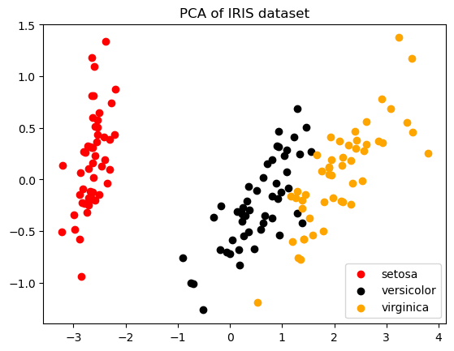

```python
plt.figure()  # 创建一个新的图形
for i in range(len(labels)):  # 对每个类别进行循环
    plt.scatter(X_dr[y==i, 0], X_dr[y==i, 1], c=colors[i], label=labels[i])  # 绘制散点图
plt.legend()  # 添加图例
plt.title('PCA of IRIS dataset')  # 添加图形标题
plt.show()  # 显示图形
```

### 6. 输出PCA模型参数n_components=2时，查看PCA重要属性

```python
# 查看 PCA 的重要属性
explained_variance_ratio = pca.explained_variance_ratio_  #表示每个主成分解释的方差的比例
singular_values = pca.singular_values_       #表示包含每个主成分的奇异值
components = pca.components_      # 表示每个主成分在原始特征空间中的权重
```

```python
# 打印重要属性
print(f"Explained variance ratio: {explained_variance_ratio}")
print(f"Singular values: {singular_values}")
print(f"Components:\n{components}")
```

```
Explained variance ratio: [0.92461872 0.05306648]
Singular values: [25.09996044  6.01314738]
Components:
[[ 0.36138659 -0.08452251  0.85667061  0.3582892 ]
 [ 0.65658877  0.73016143 -0.17337266 -0.07548102]]
```

### 7.调整PCA模型的主要参数，查看PCA重要属性的值

```python
import matplotlib.pyplot as plt

from sklearn.datasets import load_iris
from sklearn.decomposition import PCA
import pandas as pd
import numpy as np

iris = load_iris()
y = iris.target
X = iris.data
pd.DataFrame(X)
```

|  | 0 | 1 | 2 | 3 |
| --- | --- | --- | --- | --- |
| 0 | 5.1 | 3.5 | 1.4 | 0.2 |
| 1 | 4.9 | 3.0 | 1.4 | 0.2 |
| 2 | 4.7 | 3.2 | 1.3 | 0.2 |
| 3 | 4.6 | 3.1 | 1.5 | 0.2 |
| 4 | 5.0 | 3.6 | 1.4 | 0.2 |
| ... | ... | ... | ... | ... |
| 145 | 6.7 | 3.0 | 5.2 | 2.3 |
| 146 | 6.3 | 2.5 | 5.0 | 1.9 |
| 147 | 6.5 | 3.0 | 5.2 | 2.0 |
| 148 | 6.2 | 3.4 | 5.4 | 2.3 |
| 149 | 5.9 | 3.0 | 5.1 | 1.8 |

150 rows × 4 columns

#### 7.1 主要参数n_components=1

```python
pca = PCA(n_components=1)   # 创建一个PCA对象，设置降维后的维度为1
pca = pca.fit(X)
X_dr = pca.transform(X)
pd.DataFrame(X_dr)
```

|  | 0 |
| --- | --- |
| 0 | -2.684126 |
| 1 | -2.714142 |
| 2 | -2.888991 |
| 3 | -2.745343 |
| 4 | -2.728717 |
| ... | ... |
| 145 | 1.944110 |
| 146 | 1.527167 |
| 147 | 1.764346 |
| 148 | 1.900942 |
| 149 | 1.390189 |

150 rows × 1 columns

```python
colors = ["red", "black", "orange"]  # 定义三个类别的颜色, red对应目标变量y中的0,black对应1，orange对应2
labels = iris.target_names  # 将类别名称赋值给labels
```

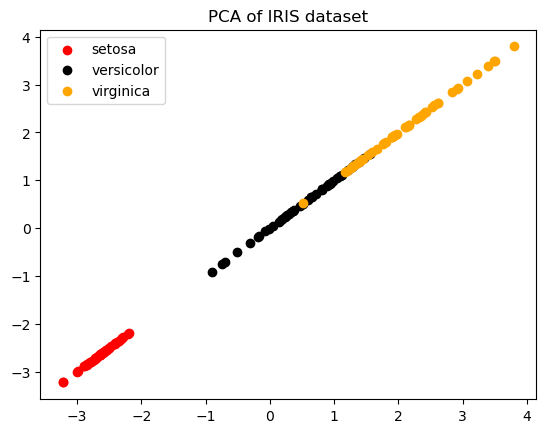

```python
plt.figure()  # 创建一个新的图形
for i in range(len(labels)):  # 对每个类别进行循环
    plt.scatter(X_dr[y==i, 0],X_dr[y==i, 0], c=colors[i], label=labels[i])  # 绘制散点图
plt.legend()  # 添加图例
plt.title('PCA of IRIS dataset')  # 添加图形标题
plt.show()  # 显示图形
```

```python
# 查看 PCA 的重要属性
explained_variance_ratio=pca.explained_variance_ratio_  #表示每个主成分解释的方差的比例
singular_values=pca.singular_values_       #表示包含每个主成分的奇异值
components=pca.components_      # 表示每个主成分在原始特征空间中的权重
# 打印重要属性
print(f"Explained variance ratio: {explained_variance_ratio}\n")
print(f"Singular values: {singular_values}\n")
print(f"Components:\n{components}")
```

```
Explained variance ratio: [0.92461872]

Singular values: [25.09996044]

Components:
[[ 0.36138659 -0.08452251  0.85667061  0.3582892 ]]
```

#### 7.2 主要参数n_components=3

```python
import matplotlib.pyplot as plt

from sklearn.datasets import load_iris
from sklearn.decomposition import PCA
import pandas as pd
import numpy as np

iris = load_iris()
y = iris.target
X = iris.data
pd.DataFrame(X)

pca = PCA(n_components=3)   # 创建一个PCA对象，设置降维后的维度为3
pca = pca.fit(X)
X_dr = pca.transform(X)
df_X_dr = pd.DataFrame(X_dr)
df_X_dr
```

|  | 0 | 1 | 2 |
| --- | --- | --- | --- |
| 0 | -2.684126 | 0.319397 | -0.027915 |
| 1 | -2.714142 | -0.177001 | -0.210464 |
| 2 | -2.888991 | -0.144949 | 0.017900 |
| 3 | -2.745343 | -0.318299 | 0.031559 |
| 4 | -2.728717 | 0.326755 | 0.090079 |
| ... | ... | ... | ... |
| 145 | 1.944110 | 0.187532 | 0.177825 |
| 146 | 1.527167 | -0.375317 | -0.121898 |
| 147 | 1.764346 | 0.078859 | 0.130482 |
| 148 | 1.900942 | 0.116628 | 0.723252 |
| 149 | 1.390189 | -0.282661 | 0.362910 |

150 rows × 3 columns

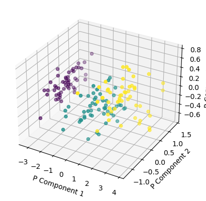

```python
from mpl_toolkits.mplot3d import Axes3D
# 创建 3D 图形
fig = plt.figure()
ax = fig.add_subplot(111, projection='3d')

# 绘制三维散点图
ax.scatter(df_X_dr[0], df_X_dr[1], df_X_dr[2], c=y, marker='o')

# 添加标签
ax.set_xlabel('P Component 1')
ax.set_ylabel('P Component 2')
ax.set_zlabel('P Component 3')

# 显示图形
plt.show()
```

```python
# 查看 PCA 的重要属性
explained_variance_ratio=pca.explained_variance_ratio_  #表示每个主成分解释的方差的比例
singular_values=pca.singular_values_       #表示包含每个主成分的奇异值
components=pca.components_      # 表示每个主成分在原始特征空间中的权重
# 打印重要属性
print(f"Explained variance ratio: {explained_variance_ratio}\n")
print(f"Singular values: {singular_values}\n")
print(f"Components:\n{components}")
```

```
Explained variance ratio: [0.92461872 0.05306648 0.01710261]

Singular values: [25.09996044  6.01314738  3.41368064]

Components:
[[ 0.36138659 -0.08452251  0.85667061  0.3582892 ]
 [ 0.65658877  0.73016143 -0.17337266 -0.07548102]
 [-0.58202985  0.59791083  0.07623608  0.54583143]]
```

#### 7.3理解

1.随着 n_components 的增加，解释方差比例增加，这表明增加主成分能够更好地保留原始数据的方差。

2.奇异值的数量与 n_components 相同，随着 n_components 的增加，解释方差比例逐渐增加。

3.主成分的权重矩阵在不同的 n_components设置下是相同的，这是因为主成分是通过奇异值分解（SVD）计算的，而奇异值和主成分都与数据的特征矩阵相关

### 8.三种方式确定PCA的超参数n_components值

#### 8.1累计可解释方差贡献率

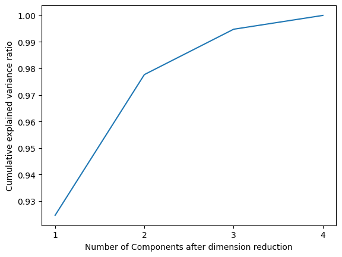

```
Number of components selected: 2
```

```python
import numpy as np
import matplotlib.pyplot as plt
from sklearn.datasets import load_iris
from sklearn.decomposition import PCA

X = load_iris().data
pca_line = PCA().fit(X)

# 绘制累计方差贡献率曲线
#np.cumsum(array) 返回一个具有相同形状的数组，其中每个元素是输入数组对应位置及之前所有元素的累积和
cumulative_variance_ratio = np.cumsum(pca_line.explained_variance_ratio_)
plt.plot([1,2,3,4],cumulative_variance_ratio)
plt.xticks([1,2,3,4]) #限制坐标轴显示为整数
plt.xlabel("Number of Components after dimension reduction")
plt.ylabel("Cumulative explained variance ratio")
plt.show()

# 选择阈值，例如95%
threshold = 0.95

# 确定主成分数量
# np.argmax() 是 NumPy 库中的一个函数，用于返回数组中最大元素的索引
n_components = np.argmax(cumulative_variance_ratio >= threshold) + 1

# 打印选择的主成分数量
print(f"Number of components selected: {n_components}")
```

#### 8.2 最大似然估计自选超参数

```python
# 用最大似然估计(maximum likelihood estimation)自选超参数的方法，
# 输入“mle”作为n_components的参数输入，就可以调用这种方法
pca_mle = PCA(n_components="mle")
pca_mle =pca_mle.fit(X)
X_mle = pca_mle.transform(X)

X_mle
```

```
array([[-2.68412563,  0.31939725, -0.02791483],
       [-2.71414169, -0.17700123, -0.21046427],
       [-2.88899057, -0.14494943,  0.01790026],
       [-2.74534286, -0.31829898,  0.03155937],
       [-2.72871654,  0.32675451,  0.09007924],
       [-2.28085963,  0.74133045,  0.16867766],
       [-2.82053775, -0.08946138,  0.25789216],
       [-2.62614497,  0.16338496, -0.02187932],
       [-2.88638273, -0.57831175,  0.02075957],
       [-2.6727558 , -0.11377425, -0.19763272],
       [-2.50694709,  0.6450689 , -0.07531801],
       [-2.61275523,  0.01472994,  0.10215026],
       [-2.78610927, -0.235112  , -0.20684443],
       [-3.22380374, -0.51139459,  0.06129967],
       [-2.64475039,  1.17876464, -0.15162752],
       [-2.38603903,  1.33806233,  0.2777769 ],
       [-2.62352788,  0.81067951,  0.13818323],
       [-2.64829671,  0.31184914,  0.02666832],
       [-2.19982032,  0.87283904, -0.12030552],
       [-2.5879864 ,  0.51356031,  0.21366517],
       [-2.31025622,  0.39134594, -0.23944404],
       [-2.54370523,  0.43299606,  0.20845723],
       [-3.21593942,  0.13346807,  0.29239675],
       [-2.30273318,  0.09870885,  0.03912326],
       [-2.35575405, -0.03728186,  0.12502108],
       [-2.50666891, -0.14601688, -0.25342004],
       [-2.46882007,  0.13095149,  0.09491058],
       [-2.56231991,  0.36771886, -0.07849421],
       [-2.63953472,  0.31203998, -0.1459089 ],
       [-2.63198939, -0.19696122,  0.04077108],
       [-2.58739848, -0.20431849, -0.07722299],
       [-2.4099325 ,  0.41092426, -0.14552497],
       [-2.64886233,  0.81336382,  0.22566915],
       [-2.59873675,  1.09314576,  0.15781081],
       [-2.63692688, -0.12132235, -0.14304958],
       [-2.86624165,  0.06936447, -0.16433231],
       [-2.62523805,  0.59937002, -0.26835038],
       [-2.80068412,  0.26864374,  0.09369908],
       [-2.98050204, -0.48795834,  0.07292705],
       [-2.59000631,  0.22904384, -0.0800823 ],
```

[output cut: 95 more lines]

```
       [ 3.07649993,  0.68808568, -0.33559229],
       [ 2.14424331,  0.1400642 ,  0.73487894],
       [ 1.90509815,  0.04930053,  0.16218024],
       [ 1.16932634, -0.16499026,  0.28183584],
       [ 2.10761114,  0.37228787,  0.02729113],
       [ 2.31415471,  0.18365128,  0.32269375],
       [ 1.9222678 ,  0.40920347,  0.1135866 ],
       [ 1.41523588, -0.57491635,  0.29632253],
       [ 2.56301338,  0.2778626 ,  0.29256952],
       [ 2.41874618,  0.3047982 ,  0.50448266],
       [ 1.94410979,  0.1875323 ,  0.17782509],
       [ 1.52716661, -0.37531698, -0.12189817],
       [ 1.76434572,  0.07885885,  0.13048163],
       [ 1.90094161,  0.11662796,  0.72325156],
       [ 1.39018886, -0.28266094,  0.36290965]])
```

#### 8.3 按信息量占比选超参数

```python
'''
输入[0,1]之间的浮点数，并让参数svd_solver =='full'，
指定降维后总解释性方差占比大于n_components指定的百分比，
即是说，希望保留百分之多少的信息量
'''
pca_f =PCA(n_components=0.97, svd_solver="full")
pca_f = pca_f.fit(X)
X_f = pca_f.transform(X) ## 将原始数据转换到主成分空间
pca_f.explained_variance_ratio_
```

```
array([0.92461872, 0.05306648])
```

### 9.比较PCA与SVD降维的原理，理解PCA中的SVD参数

#### PCA降维：

1. PCA使用方差作为信息量的衡量指标，并且用特征值分解来找出空间V。
2. 对协方差矩阵进行特征值分解，得到特征值和特征向量。特征向量构成了新的基，称为主成分，而特征值表示数据在每个主成分上的方差。
3. 选择前k个最大的特征值及对应的特征向量，构成一个投影矩阵。将原始数据乘以这个投影矩阵，即可将数据降至k维空间。 #### SVD降维：
4. SVD使用奇异值分解来找出空间V。得到三个矩阵 U、Σ、V，其中 U 和 V 是正交矩阵，Σ 是对角矩阵。
5. 对角矩阵Σ的对角元素即为奇异值，它们表示了数据在每个主成分上的重要性。
6. 选择前k个最大的奇异值及对应的列向量，构成一个投影矩阵。将原始数据矩阵乘以这个投影矩阵，即可将数据降至k维空间。

   在数学原理中，无论是PCA和SVD都需要遍历所有的特征和样本来计算信息量指标。 并且在矩阵分解过程中，会产生比原来的特征矩阵更大的矩阵，比如原数据的结构是(m,n)，在矩阵分解中为了找出最佳新特征空间V，可能需要产生(n,n) ，(m,m)大小的矩阵，还需要产生协方差矩阵去计算更多的信息。

#### PCA中的SVD：

1. PCA和SVD涉及了大量的矩阵计算，两者都是运算量很大的模型。
2. SVD可以跳过数学神秘的宇宙，不计算协方差矩阵，直接找出一个新特征向量组成的n维空间，而这个n维空间就是奇异值分解后的右矩阵。
3. 奇异值分解可以不计算协方差矩阵等结构复杂计算冗长的矩阵，就直接求出新特征空间和降维后的特征矩阵。
4. SVD矩阵分解的过程比PCA简单快速。但是遗憾的是，SVD的信息量衡量指标比较复杂，要理解“奇异值”远不如理解“方差”来得容易。

因此，sklearn将降维流程拆成了两部分：一部分是计算特征空间V，由奇异值分解完成；另一部分是映射数据和求解新特征矩阵，由主成分分析完成，实现了用SVD的性质减少计算量，却让信息量的评估指标是方差。